# Выявление закономерности успешности продаж игр на различных игровых платформах

### Составление портрета пользователя каждого региона

Составим портреты пользователей Северной Америки, Европы и Японии по полулярности платформ, жанров и рейтинга игр в данных регионах.

#### Портрет пользователя Северной Америки (NA)

Самые популярные платформы (топ-5)

```
              na
platform
PS4       108.74
XOne       93.12
X360       81.66
PS3        63.50
3DS        38.20
```

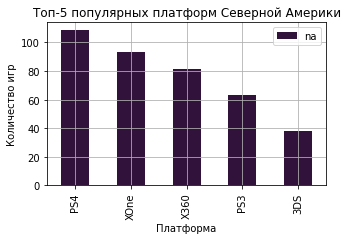

```python
platforms_na = actual_period.pivot_table(index = 'platform', values = 'na', aggfunc = 'sum').sort_values('na', ascending=False)
print(platforms_na.iloc[0:5])
platforms_na.iloc[0:5].plot(kind='bar', grid=True, colormap="turbo", title = 'Топ-5 популярных платформ Северной Америки', xlabel = 'Платформа', ylabel = 'Количество игр', figsize=(5,3));
```

Самые популярные жанры (топ-5)

```
                  na
genre
Action        126.05
Shooter       109.74
Sports         65.27
Role-Playing   46.40
Misc           27.49
```

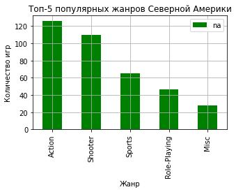

```python
genre_na = actual_period.pivot_table(index = 'genre', values = 'na', aggfunc = 'sum').sort_values('na', ascending=False)
genre_na.iloc[0:5]
print(genre_na.iloc[0:5])
genre_na.iloc[0:5].plot(kind='bar', grid=True, color="green", title = 'Топ-5 популярных жанров Северной Америки', xlabel = 'Жанр', ylabel = 'Количество игр', figsize=(5,3));
```

Определим, влияет ли рейтинг ESRB на продажи Северной Америке

```
            na
rating
M       165.21
RP       89.42
E        79.05
E10+     54.24
T        49.79
```

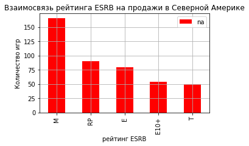

```python
ESRB_na = actual_period.pivot_table(index = 'rating', values = 'na', aggfunc = 'sum').sort_values('na', ascending=False)
print(ESRB_na)
ESRB_na.plot(kind='bar', grid=True, color="red", title = 'Взаимосвязь рейтинга ESRB на продажи в Северной Америке', xlabel = 'рейтинг ESRB', ylabel = 'Количество игр', figsize=(5,3));
```

##### Вывод по портрету пользователя Северной Америки (NA)

*Можно предположить, что портрет Северной Америки - взрослые, не младше 17 лет, играющие на платформе PS4 в игры жанром Action.*

#### Портрет пользователя Европы (EU)

Самые популярные платформы (топ-5)

```
              eu
platform
PS4       141.09
PS3        67.81
XOne       51.59
X360       42.52
3DS        30.96
```

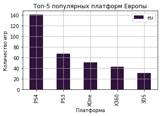

```python
platforms_eu = actual_period.pivot_table(index = 'platform', values = 'eu', aggfunc = 'sum').sort_values('eu', ascending=False)
print(platforms_eu.iloc[0:5])
platforms_eu.iloc[0:5].plot(kind='bar', grid=True, colormap="turbo", title = 'Топ-5 популярных платформ Европы', xlabel = 'Платформа', ylabel = 'Количество игр', figsize=(5,3));
```

Самые популярные жанры (топ-5)

```
                  eu
genre
Action        118.13
Shooter        87.86
Sports         60.52
Role-Playing   36.97
Racing         20.19
```

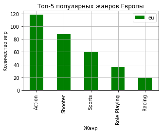

```python
genre_eu = actual_period.pivot_table(index = 'genre', values = 'eu', aggfunc = 'sum').sort_values('eu', ascending=False)
genre_eu.iloc[0:5]
print(genre_eu.iloc[0:5])
genre_eu.iloc[0:5].plot(kind='bar', grid=True, color="green", title = 'Топ-5 популярных жанров Европы', xlabel = 'Жанр', ylabel = 'Количество игр', figsize=(5,3));
```

Определим, влияет ли рейтинг ESRB на продажи Европы

```
            eu
rating
M       145.32
E        83.36
RP       78.91
E10+     42.69
T        41.95
```

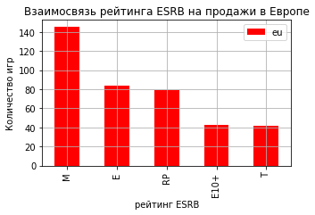

```python
ESRB_eu = actual_period.pivot_table(index = 'rating', values = 'eu', aggfunc = 'sum').sort_values('eu', ascending=False)
print(ESRB_eu)
ESRB_eu.plot(kind='bar', grid=True, color="red",title = 'Взаимосвязь рейтинга ESRB на продажи в Европе', xlabel = 'рейтинг ESRB', ylabel = 'Количество игр', figsize=(5,3));
```

##### Вывод по портрету пользователя Европы (EU)

*Можно предположить, что портрет Европы - взрослые, достигшие 17 лет, играющие на платформе PS4 в игры жанром Action.*

#### Портрет пользователя Японии (JP)

Самые популярные платформы (топ-5)

```
             jp
platform
3DS       67.81
PS3       23.35
PSV       18.59
PS4       15.96
WiiU      10.88
```

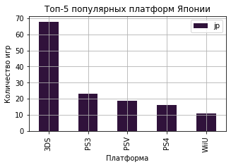

```python
platforms_jp = actual_period.pivot_table(index = 'platform', values = 'jp', aggfunc = 'sum').sort_values('jp', ascending=False)
print(platforms_jp.iloc[0:5])
platforms_jp.iloc[0:5].plot(kind='bar', grid=True, colormap="turbo", title = 'Топ-5 популярных платформ Японии', xlabel = 'Платформа', ylabel = 'Количество игр',figsize=(5,3));
```

Самые популярные жанры (топ-5)

```
                 jp
genre
Role-Playing  51.04
Action        40.49
Misc           9.20
Fighting       7.65
Shooter        6.61
```

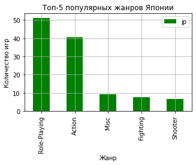

```python
genre_jp = actual_period.pivot_table(index = 'genre', values = 'jp', aggfunc = 'sum').sort_values('jp', ascending=False)
genre_jp.iloc[0:5]
print(genre_jp.iloc[0:5])
genre_jp.iloc[0:5].plot(kind='bar', grid=True, color="green", title = 'Топ-5 популярных жанров Японии', xlabel = 'Жанр', ylabel = 'Количество игр', figsize=(5,3));
```

Определим, влияет ли рейтинг ESRB на продажи Японии

```
           jp
rating
RP      85.05
T       20.59
E       15.14
M       14.11
E10+     5.89
```

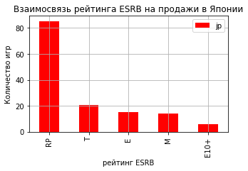

```python
ESRB_jp = actual_period.pivot_table(index = 'rating', values = 'jp', aggfunc = 'sum').sort_values('jp', ascending=False)
print(ESRB_jp)
ESRB_jp.plot(kind='bar', grid=True, color="red", title = 'Взаимосвязь рейтинга ESRB на продажи в Японии', xlabel = 'рейтинг ESRB', ylabel = 'Количество игр', figsize=(5,3));
```

##### Вывод по портрету пользователя Японии (JP)

- Самой популярной платформой в Японии является 3DS. Также в пятерку популярных, кроме платформы 3DS, входят: PS3, PSV, PS4, WiU.
- Самым популярным жанром игр в Японии является Role-Playing. Также в пятерку популярных, кроме Role-Playing, входят: Action, Misc, Fighting, Shooter.
- В Японии игры пользются популярностью с рейтингом ESRB - "RP", то есть игры, которые еще не получили рейтинг - находятся в ожидании. Можно предположить, что в Японии любят новинки.

*Можно предположить, что портрет Японии - люди, играющие на платформе 3DS в игры жанром Role-Playing.*

**Выведем диаграммы топ-5 популяных платформ в регионах**

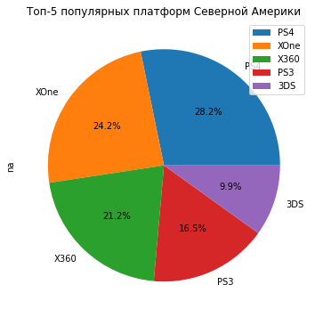

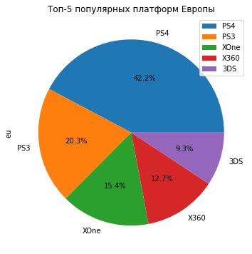

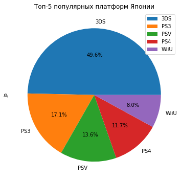

```python
platforms_na.iloc[0:5].plot(kind='pie', y = 'na', title = 'Топ-5 популярных платформ Северной Америки', autopct='%1.1f%%', figsize=(6,6));
platforms_eu.iloc[0:5].plot(kind='pie', y = 'eu', title = 'Топ-5 популярных платформ Европы', autopct='%1.1f%%', figsize=(6,6));
platforms_jp.iloc[0:5].plot(kind='pie', y = 'jp', title = 'Топ-5 популярных платформ Японии', autopct='%1.1f%%', figsize=(6,6));
```

**Выведем диаграммы топ-5 популяных жанров в регионах**

[output not shown]

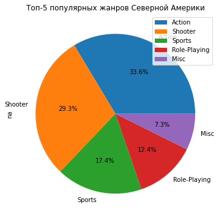

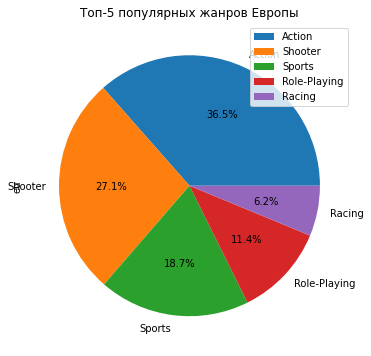

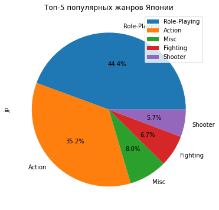

```python
genre_na.iloc[0:5].plot(kind='pie', y = 'na', title = 'Топ-5 популярных жанров Северной Америки', autopct='%1.1f%%', figsize=(6,6));
genre_eu.iloc[0:5].plot(kind='pie', y = 'eu', title = 'Топ-5 популярных жанров Европы', autopct='%1.1f%%', figsize=(6,6));
genre_jp.iloc[0:5].plot(kind='pie', y = 'jp', title = 'Топ-5 популярных жанров Японии', autopct='%1.1f%%', figsize=(6,6));
```

#### Общий вывод по портретам пользователей каждого региона

По составленным портретам видно, что в Северной Америке и Европе предпочтения платформ, жанров игр, а также возрастная категория людей, предпочитающих играть в игры, совпадает. В то время, как у Японии другие предпочтения как в жанре, так и самой платформе.

- Портрет Северной Америки - взрослые, достигшие 17 лет, играющие на платформе PS4 в игры жанром Action.
- Портрет Европы - взрослые, достигшие 17 лет, играющие на платформе PS4 в игры жанром Action.
- Портрет Японии - люди, играющие на платформе 3DS в игры жанром Role-Playing.

### Проверка гипотез

**Перед проверкой гипотез необходиомо сформулировать нулевую и альтернативную гипотезы.** В двух представленных задачах необходимо проверить равенство/неравенство среднего двух генеральных совокупностей, то есть, либо равно, либо не равно. В таком случае, в качестве нулевой гипотезы принимается, что среднее двух генеральных совокупностей равны, а в качестве альтернативной , наоборот, что среднее двух генеральных совокупностей не равны, то есть такая гипотеза является двусторонней, потому предполагает возможное отклонение и в большую, и в меньшую стороны.

**После формулировки нулевой и альтернативной гипотез, определимся каким методом будем проверять гипотезы в представленных задачах.** Рассмотрим представленные генеральные совокупности:

- генеральные совокупности не зависят друг от друга;
- выборочные средние нормально распределены;
- выборки достаточно велики и примерно равны по размеру между собой.

Таким образом, под описанные выше условия подходит метод для проверки гипотезы о равенстве среднего двух генеральных совокупностей по взятым из них выборкам `scipy.stats.ttest_ind`

#### Гипотеза №1 - Средние пользовательские рейтинги платформ Xbox One (XOne) и PC одинаковые

- За нулевую гипотезу примем: средний рейтинг "XOne" = средний рейтинг "PC"
- За альтернативную гипотезу примем: средний рейтинг "XOne" ≠ средний рейтинг "PC"

Для проверки гипотез будем применять метод о равенстве среднего двух генеральных совокупностей.

```python
rating_XOne = actual_period[(actual_period['platform'] == 'XOne') & (actual_period['user_score'] > 0)]['user_score']
rating_PC = actual_period[(actual_period['platform'] == 'PC') & (actual_period['user_score'] > 0)]['user_score']
```

```python
alpha = 0.05 # уровень статистической значимости
# если p-value окажется меньше него, отвергнем гипотезу

results = st.ttest_ind(rating_XOne, rating_PC)

print('p-значение:', results.pvalue)

if results.pvalue < alpha:
    print('Отвергаем нулевую гипотезу')
else:
    print('Не получилось отвергнуть нулевую гипотезу')
```

```
p-значение: 0.14012658403611647
Не получилось отвергнуть нулевую гипотезу
```

```python
print('Cредний рейтинг "XOne":', rating_XOne.mean().round(4))
print('Cредний рейтинг "PC":',rating_PC.mean().round(4))
```

```
Cредний рейтинг "XOne": 6.5214
Cредний рейтинг "PC": 6.2697
```

#### Гипотеза №2 - Средние пользовательские рейтинги жанров Action (англ. «действие», экшен-игры) и Sports (англ. «спортивные соревнования») разные.

- За нулевую гипотезу примем: средний рейтинг "Action" = средний рейтинг "Sports"
- За альтернативную гипотезу примем: средний рейтинг "Action" ≠ средний рейтинг "Sports"

Для проверки гипотез будем применять метод о равенстве среднего двух генеральных совокупностей.

```python
rating_Action = actual_period[(actual_period['genre'] == 'Action') & (actual_period['user_score'] > 0)]['user_score']
rating_Sports = actual_period[(actual_period['genre'] == 'Sports') & (actual_period['user_score'] > 0)]['user_score']
```

```python
alpha = 0.05 # уровень статистической значимости
# если p-value окажется меньше него, отвергнем гипотезу

results = st.ttest_ind(rating_Action, rating_Sports)

print('p-значение:', results.pvalue)

if results.pvalue < alpha:
    print('Отвергаем нулевую гипотезу')
else:
    print('Не получилось отвергнуть нулевую гипотезу')
```

```
p-значение: 1.0517832389140023e-27
Отвергаем нулевую гипотезу
```

```python
print('Cредний рейтинг "Action":', rating_Action.mean().round(4))
print('Cредний рейтинг "Sports":',rating_Sports.mean().round(4))
```

```
Cредний рейтинг "Action": 6.8375
Cредний рейтинг "Sports": 5.2381
```

### Общий вывод

**При изучении общей информации о датасете, мы получили следуюшие данные:**

- Имеем 16715 строк и 11 колонок.
- Данные имеют пропущенные значения, а также не все столбцы имеют правильный тип данных.

**По итогам предобработки данных, мы добились следующих результатов:**

- Заменили названия столбцов.
- Преобразовали типы данных в столбцах `year` и `user_score`, так как год - целочисленное значение, а оценка пользователей - численное значение с плавающей запятой.
- В столбце `year` избавились от пропусков, удалив строки, так как количество таких пропусков не существенно. В столбцах name и genre избавились от пропусков, удалив эти сторки из датасета (их количество равнялось двум сторкам).
- Аббревиатуру в столбце `user_score` "tbd" заменили на значение "nan", так как она обозначает To Be Determined, то есть "Будет определено", но пока неизвестно.
- Причины пропусков в столбцах `critic_score`, `user_score`, `rating`, скорее всего, связаны с тем, что многие игры были выпущены в 90-е годы, когда критики еще не совсем добрались до игр, также и пользователи, которые свои отзывы обычно оставляют в соц.сетях. Рейтинги ESRB начали происваивать играм с 1994 года, поэтому пропуски рейтингов у игр до 1994 неизбежны.
- Посчитали суммарные продажи во всех регионах.

**В ходе исследовательского анализа данных было выявлено следующее:**

- Наиболее часто игры выпускались в 2008 и 2009 годах, реже всего игры выпускались начиная с 1980 по 1993 включительно
- Средний срок жизни платформы составляет 7 лет. Пик по продажам платформы обычно длится 4-5 лет
- Актуальным периодом для прогноза продаж на 2017 год можно считать 2013-2016 гг.
- Лидируют по продажам платформы PS3, PS4, X360, Wii
- К потенциально прибыльным платформам можно отнести PS4, РС и X360
- Существенную взаимосвязь стоит отметить между отзывами критиков и продажами внутри одной популярной платформы
- Наблюдается взаимосвязь между отзывами критиков и отзывами пользователей
- Наблюдается достаточно слабая взаимосвязь между отзывами пользователей и продажами внутри одной популярной платформы
- Наиболее прибыльные жанры игр - Shooter, Platform, Sports. Наименее прибыльные жанры - Adventure, Puzzle.

**По итогам составления портрета пользователя каждого региона, можно отметить следующее:**

- Портрет Северной Америки - взрослые, достигшие 17 лет, играющие на платформе PS4 в игры жанром Action.
- Портрет Европы - взрослые, достигшие 17 лет, играющие на платформе PS4 в игры жанром Action.
- Портрет Японии - люди, играющие на платформе 3DS в игры жанром Role-Playing.

**При проверке гипотез, мы получили следующие результаты:**

**По итогам исследования, для прогноза будущих продаж, лучше акцентировать внимание на платформу PS4 с играми жанра Shooter с рейтингом ESRB "М", означающий, что игры для взрослых, не младше 17 лет. Также популярностью пользуются игры на платформу PS4 жанра Sports и Action с рейтингом ESRB "М".**